# Brownlows Bets

Lelainy Saavedra

November 12, 2020

### 0.0.1 2020-11-13

# 1 Introduction

At the first day of class there are 35 students in Math Statistics class and professor Brownlow always proposes this bet to his students "I will wager $2 to your bet of $1 that at least two people in today’s class have the same birthday. He tells me he has made that bet 637 times so far. Where do you think his profits are? Discuss this in a markdown document he has now $637.

This criterion is linked to a Learning OutcomeReport git commit structure There are 3 questions and there should be at least 3 separate commits, at least one dealing with each of the 3 questions. 1. What are the fair odds for a bet on matching birthdays in a 35 person class. 2. For what size class is a 2:1 odds bet fair. 3. How much money would Brownlow be expected to end up with if the bets went as described. We will solve this problem by re-sampling.  
we will set up days of the year,pick a random sample of 35, and see if two or more have the same birthday.

```r
daysYEAR=1:365
bDAYS=sample(daysYEAR,35,replace=TRUE)
length(unique(bDAYS))
```

```
## [1] 32
```

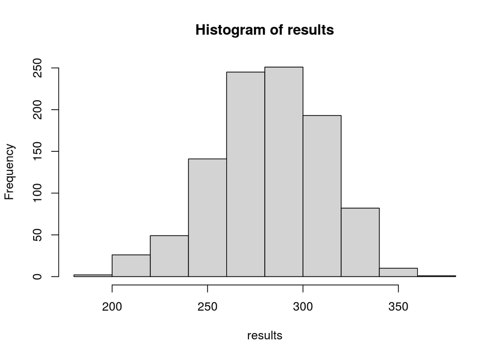

```r
results=vector("numeric")
for(j in 1:1000){


bank=0
for(i in 1:637){
class=sample(daysYEAR,35,replace=TRUE)
n=length(unique(class))
if(n == 35)bank=bank-2
else bank=bank +1
}
results[j]=bank
}
hist(results)
```

# 2 Methods

# 3 Profit Estimate

```r
favstats(results)
```

```
##  min     Q1 median  Q3 max    mean       sd    n missing
##  193 264.25    286 304 367 282.694 29.06867 1000       0
```

The expected amount of money is 282.694

#95%

```r
results=vector("numeric")
for(j in 1:1000){


bank=0
for(i in 1:637){
class=sample(daysYEAR,35,replace=TRUE)
n=length(unique(class))
if(n == 35)bank=bank-2
else bank=bank +1
}
results[j]=bank
}
sortRESULTS=sort(results)
lcl=sortRESULTS[25]
ucl=sortRESULTS[975]
```

lower confidence limit= 223  
upper confidence limit= 334

#fair odds pay off

```r
daysYEAR=1:365
bDAYS=sample(daysYEAR,35,replace=TRUE)
length(unique(bDAYS))
```

```
## [1] 35
```

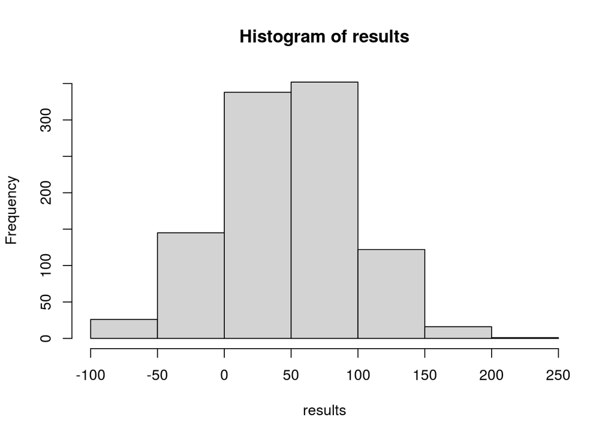

```r
results=vector("numeric")
for(j in 1:1000){


bank=0
for(i in 1:637){
class=sample(daysYEAR,35,replace=TRUE)
n=length(unique(class))
if(n == 35)bank=bank-4
else bank=bank +1
}
results[j]=bank
}
hist(results)
```

```r
daysYEAR=1:365
bDAYS=sample(daysYEAR,35,replace=TRUE)
length(unique(bDAYS))
```

```
## [1] 35
```

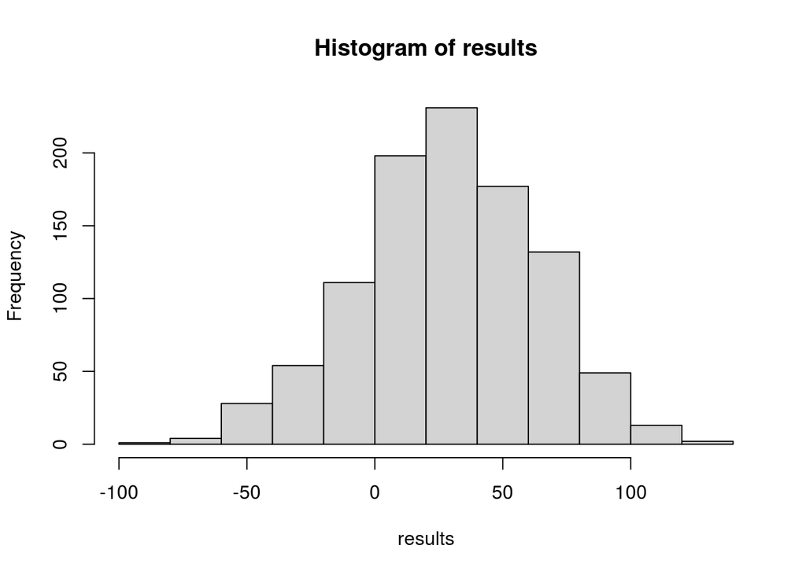

```r
results=vector("numeric")
for(j in 1:1000){


bank=0
for(i in 1:637){
class=sample(daysYEAR,29,replace=TRUE)
n=length(unique(class))
if(n == 29)bank=bank-2
else bank=bank +1
}
results[j]=bank
}
hist(results)
```

# Confidence interval of Brownlows earning

We have been using Histograms to determine the 95% confidence interval, by changing the amount of students we can also determine if it is a fair bet or not.  
# Discussion and Conclusion